# Notebook 2

## Moyens mis en oeuvre par les états

### Introduction

Grace à la *World Health Organization*, nous avons pu récupérer des données sur les moyens mis en oeuvre par les états pour venir en aide aux personnes en situation de maladie mentale. En effet, la dépression est considérée comme une maladie mentale. Nous pensons donc que le nombre d'infrastructures liées à ces maladies peut être corrélés au nombres de suicides.

```python
import matplotlib
import matplotlib.pyplot as plt
import pandas as pd
```

```python
Gouv = pd.read_csv('./Data/gouv.csv', sep=',')
Gouv = Gouv[Gouv.Year == 2016]
Gouv.head()
```

|  | Country | Year | Government expenditures on mental hospitals as a percentage of total government expenditures on mental health (%) | Stand-alone law for mental health | Year the law was enacted (latest revision) | Stand-alone policy or plan for mental health | Publication year of the policy or plan (latest revision) |
| --- | --- | --- | --- | --- | --- | --- | --- |
| 0 | Afghanistan | 2016 | NaN | Yes | 1987 | Yes | 2016.0 |
| 2 | Albania | 2016 | NaN | Yes | 2012 | Yes | 2013.0 |
| 4 | Algeria | 2016 | NaN | Yes | 1905 | No | NaN |
| 6 | Angola | 2016 | NaN | No | NaN | No | NaN |
| 7 | Antigua and Barbuda | 2016 | 8.0 | Yes | 1957 | Yes | 2013.0 |

Sur ces données, on peut notamment ressortir les pays qui présentent ou non des lois pour protéger les personnes atteintes de maladie mentales. On peut donc légitimement penser que les personnes dépressives auront plus de chance d'être prises en charge ce qui y impliquerait un taux de suicide moins important.

```python
Law = Gouv.iloc[:,[0,3]]#on récupère unqiuement la colonne qui nous intéresse.
Law.groupby(['Stand-alone law for mental health']).count()
```

| Stand-alone law for mental health | Country |
| --- | --- |
| No | 43 |
| Yes | 73 |

On peut maintenant séparer les pays ayant voté une loi de protection des personnes atteintes de maladies mentales des autres pays. On exclut les pays dont on ne possède pas les données afin de pouvoir établir une corrélation.

```python
dfYes = Law[Law['Stand-alone law for mental health'] == 'Yes']
dfNo = Law[Law['Stand-alone law for mental health'] == 'No']
```

Maintenant on compare les statistiques de suicide dans les pays ayant voté ou non des lois pour la protection de la santé mentale.

```python
#On prépare le DataFrame pour le merge
Suicide = pd.read_csv('./Data/taux_sexe(age).csv', sep=',')
Suicide = Suicide.iloc[1:,0:3]
Suicide.columns=['Country','Sexe','Suicide rate (per 100k people)']
Suicide = Suicide[Suicide.Sexe == 'Both sexes']#on récupère que les ligne possédant "both sexe" afin de s'interessé
# à une population globale sans prendre ne compte le facteur du genre
Suicide = Suicide.iloc[:,[0,2]]
Suicide.head()
```

|  | Country | Suicide rate (per 100k people) |
| --- | --- | --- |
| 1 | Afghanistan | 6.4 |
| 4 | Albania | 5.6 |
| 7 | Algeria | 3.3 |
| 10 | Angola | 8.9 |
| 13 | Antigua and Barbuda | 0.5 |

On procède donc à une spéaration de notre échantillon de pays en 2 catégorie :

-dans un premiers temps les pays ayant adopté des lois venant en aide au personne depressif regroupé dans "SuicideYes"

-les pays n'ayant pas adopté ces lois regroupé dans "SuicidesNo"

```python
SuicideYes = Suicide.merge(dfYes, left_on = 'Country', right_on = 'Country')
SuicideYes = SuicideYes.iloc[:,0:2]
SuicideYes.columns = ['Pays ayant voté une loi pour la protection de la santé mentale', 'Taux de suicide (pour 100k personnes)']
SuicideNo = Suicide.merge(dfNo, left_on = 'Country', right_on = 'Country')
SuicideNo = SuicideNo.iloc[:,0:2]
SuicideNo.columns = ["Pays n'ayant pas voté une loi pour la protection de la santé mentale", 'Taux de suicide (pour 100k personnes)']
SuicideNo.head()
```

|  | Pays n'ayant pas voté une loi pour la protection de la santé mentale | Taux de suicide (pour 100k personnes) |
| --- | --- | --- |
| 0 | Angola | 8.9 |
| 1 | Bangladesh | 6.1 |
| 2 | Belize | 5.9 |
| 3 | Bhutan | 11.6 |
| 4 | Bolivia (Plurinational State of) | 12.9 |

résumé statistique des pays ayant adopté les lois

```python
SuicideYes.describe()
```

|  | Taux de suicide (pour 100k personnes) |
| --- | --- |
| count | 70.000000 |
| mean | 9.505714 |
| std | 6.004633 |
| min | 0.500000 |
| 25% | 5.400000 |
| 50% | 8.050000 |
| 75% | 12.550000 |
| max | 30.200000 |

résumé statistique des pays n'ayant pas adopté les lois

```python
SuicideNo.describe()
```

|  | Taux de suicide (pour 100k personnes) |
| --- | --- |
| count | 43.00000 |
| mean | 9.60000 |
| std | 4.21686 |
| min | 2.40000 |
| 25% | 6.70000 |
| 50% | 9.30000 |
| 75% | 12.55000 |
| max | 23.00000 |

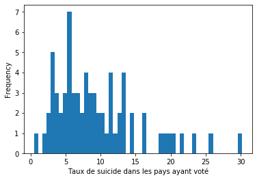

```python
import numpy as np
import matplotlib.pyplot as plt
SuicideYes.iloc[:,1].plot.hist(bins=50);
plt.xlabel('Taux de suicide dans les pays ayant voté');
```

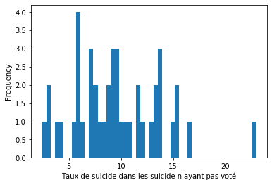

```python
SuicideNo.iloc[:,1].plot.hist(bins=50);
plt.xlabel("Taux de suicide dans les suicide n'ayant pas voté");
```

On remarque que les lois votées ou non ont peu d'impact sur le taux de suicide dans le pays. En effet, la moyenne des pays ayant voté en faveur d'une loi est à peine inférieur à celle des pays ne l'ayant pas voté.

Il est compliqué de démêler les deux influences suivantes :

- Les lois sont votées lorsque le taux de suicide est **élevé** : c'est un enjeu majeur
- Le taux de suicide **diminue** lorsque les lois sont votées et appliquées

Les lois ne sont pas les seuls moyen qu'ont les gouvernement d'aider, des aides hospitalières peuvent aussi être fournies, nous allons donc essayé de lier le taux de suicide au nombre de centre hospitalier pour un certain nombre de personne ainsi que le nombre de personne disponible pour aider les personnes dans le besoin psychologiquement que nous appellerons "day treatment"

```python
Facilities = pd.read_csv('./Data/facilities.csv', sep=',')
Doctor = pd.read_csv('./Data/docteurs.csv', sep=',')
Facilities = Facilities.iloc[:,[0,3]]
Facilities=Facilities.dropna()
Facilities.columns = ['Country', 'Mental hospital per 100k population']
Facilities.head()
```

|  | Country | Mental hospital per 100k population |
| --- | --- | --- |
| 0 | Afghanistan | 0.012 |
| 1 | Albania | 0.068 |
| 2 | Algeria | 0.068 |
| 5 | Argentina | 1.071 |
| 6 | Armenia | 0.069 |

```python
FaciliSuicide = Facilities.merge(Suicide, left_on = 'Country', right_on = 'Country')
FaciliSuicide.columns = ['Country','Mental_Hospitals','Suicide_Rate']
FaciliSuicide.describe()
```

|  | Mental_Hospitals | Suicide_Rate |
| --- | --- | --- |
| count | 136.000000 | 136.000000 |
| mean | 0.300684 | 9.417647 |
| std | 0.513116 | 5.169066 |
| min | 0.006000 | 0.400000 |
| 25% | 0.042000 | 5.600000 |
| 50% | 0.136000 | 9.050000 |
| 75% | 0.397250 | 12.350000 |
| max | 4.542000 | 30.200000 |

Classe 1 : 25% des pays avec le plus petit nombre de "mental hospital" Classe 2 : Pays entre 25% et 50% Classe 3 : Pays entre 50% et 75% Classe 4 : Pays entre 75% et 100%

```python
FaciliSuicide=FaciliSuicide.sort_values(by = 'Mental_Hospitals')
Classe1 = FaciliSuicide.iloc[0:int(131*25/100),-1]
Classe2 = FaciliSuicide.iloc[int(131*25/100):int(131*50/100),-1]
Classe3 = FaciliSuicide.iloc[int(131*50/100):int(131*75/100),-1]
Classe4 = FaciliSuicide.iloc[int(131*75/100):int(131),-1]
dfClasse1=pd.DataFrame(Classe1.describe())
dfClasse1.columns=['Classe1']

dfClasse2=pd.DataFrame(Classe2.describe())
dfClasse2.columns = ['Classe2']

dfClasse3 = pd.DataFrame(Classe3.describe())
dfClasse3.columns = ['Classe3']

dfClasse4 = pd.DataFrame(Classe4.describe())
dfClasse4.columns = ['Classe4']

SPH=pd.concat([dfClasse1,dfClasse2],axis=1)
SPH=pd.concat([SPH,dfClasse3],axis=1)
SPH=pd.concat([SPH,dfClasse4],axis=1)
SPH
```

|  | Classe1 | Classe2 | Classe3 | Classe4 |
| --- | --- | --- | --- | --- |
| count | 32.000000 | 33.000000 | 33.000000 | 33.000000 |
| mean | 9.312500 | 8.836364 | 9.112121 | 10.300000 |
| std | 5.161817 | 4.708955 | 5.783855 | 5.347955 |
| min | 2.400000 | 2.000000 | 0.400000 | 1.700000 |
| 25% | 5.875000 | 5.600000 | 4.500000 | 6.100000 |
| 50% | 8.650000 | 7.900000 | 8.600000 | 10.400000 |
| 75% | 11.825000 | 11.500000 | 12.900000 | 13.800000 |
| max | 23.000000 | 21.400000 | 30.200000 | 25.700000 |

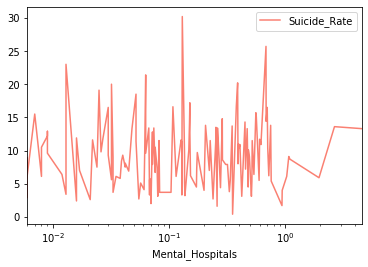

```python
FaciliSuicide.plot(kind='line',x='Mental_Hospitals',y='Suicide_Rate',color='salmon',logx=True);
plt.savefig('NB2_0.png')
```

On peut observer que le nombre de lieu d'acceuil pour personnes possédant des problème psychologique n'influe pas ou très peu sur le taux de suicide. Il reste sensiblement le même, même si on observe une augmentation entre la classe 1 à la classe 4 pouvant s'expliquer par un plus grand besoin d'infrastructure dans les pays ou le suicde est plus courant

On réitère le procédé pour les day treatment.

```python
Faci = pd.read_csv('./Data/facilities.csv', sep=',')
Doctor = pd.read_csv('./Data/docteurs.csv', sep=',')
Faci = Faci.iloc[:,[0,4]]
Faci=Faci.dropna()
Faci.columns = ['Country', 'day treatment per 100k population']
Faci.head()
```

|  | Country | day treatment per 100k population |
| --- | --- | --- |
| 0 | Afghanistan | 0.006 |
| 1 | Albania | 0.410 |
| 2 | Algeria | 0.048 |
| 5 | Argentina | 1.720 |
| 6 | Armenia | 1.371 |

```python
FaciSuicide = Faci.merge(Suicide, left_on = 'Country', right_on = 'Country')
FaciSuicide.columns = ['Country','day_treatment','Suicide_Rate']
FaciSuicide.describe()
```

|  | day_treatment | Suicide_Rate |
| --- | --- | --- |
| count | 135.000000 | 135.000000 |
| mean | 1.897778 | 9.378519 |
| std | 3.359574 | 5.482909 |
| min | 0.006000 | 0.400000 |
| 25% | 0.128500 | 5.550000 |
| 50% | 0.691000 | 8.400000 |
| 75% | 2.180500 | 12.850000 |
| max | 20.475000 | 30.200000 |

```python
FaciSuicide=FaciSuicide.sort_values(by ='day_treatment')
Classe12 = FaciSuicide.iloc[0:int(131*25/100),-1]
Classe22 = FaciSuicide.iloc[int(131*25/100):int(131*50/100),-1]
Classe32 = FaciSuicide.iloc[int(131*50/100):int(131*75/100),-1]
Classe42 = FaciSuicide.iloc[int(131*75/100):int(131),-1]
dfClasse12=pd.DataFrame(Classe12.describe())
dfClasse12.columns=['Classe1']

dfClasse22=pd.DataFrame(Classe22.describe())
dfClasse22.columns = ['Classe2']

dfClasse32 = pd.DataFrame(Classe32.describe())
dfClasse32.columns = ['Classe3']

dfClasse42 = pd.DataFrame(Classe42.describe())
dfClasse42.columns = ['Classe4']
```

```python
SPD2=pd.concat([dfClasse12,dfClasse22],axis=1)
SPD2=pd.concat([SPD2,dfClasse32],axis=1)
SPD2=pd.concat([SPD2,dfClasse42],axis=1)
SPD2
```

|  | Classe1 | Classe2 | Classe3 | Classe4 |
| --- | --- | --- | --- | --- |
| count | 32.000000 | 33.000000 | 33.000000 | 33.000000 |
| mean | 10.571875 | 8.909091 | 8.554545 | 9.309091 |
| std | 4.665331 | 6.501508 | 4.061180 | 6.352330 |
| min | 3.300000 | 1.600000 | 2.700000 | 0.400000 |
| 25% | 7.300000 | 3.700000 | 5.700000 | 4.500000 |
| 50% | 9.600000 | 7.200000 | 8.400000 | 8.700000 |
| 75% | 13.000000 | 11.500000 | 10.500000 | 13.300000 |
| max | 23.000000 | 30.200000 | 20.000000 | 26.500000 |

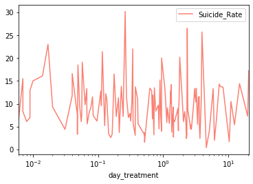

```python
FaciSuicide.plot(kind='line',x='day_treatment',y='Suicide_Rate',color='salmon', logx=True);
plt.savefig('NB2_1.png')
```

On peut observer une faible influence pour ce facteur seul cependant on peut noter que le minimum est très inferieur dans les pays avec le plus de day treatment ce qui peut vouloir dire que les day treatment ont un impact dans certain pays. De plus la moyenne de taux de suicide est plus élevé dans la classe 1 ce qui est cohérent puisque ce sont les pays ayant mis moins de moyen à disposition.

# CONCLUSION

On peut conclure que les moyens apporté n'ont que très peu d'impact direct sur le taux de suicde mais sont plutot des réponses au problème du suicide il st donc compliqué de pouvoir analyser le réel impact qu'ont les moyens mis à disposition par le gouvrernement